# Factors Influencing a Countries' Happiness

Tutorial by Ravi Rosyidi

## Motivation

Happiness is universally a postive emotion. One does not feel content with life without some form of happiness. Personally, with quaratine shutting down my social life, exposing corrupt politicans, and even destroying many countries economics, I wondered if there was any correlation between those factors and my lack of happiness. It's also not just my happiness but many of my friends, teachers, and co-workers. In fact, society as a whole has, in my opinion, been frustrated, stressed, and unhappy with the world. I would like to know the factors that influnece a societies happiness and differetiate each factor to better understand what drivers a society. After all, happiness is the emotion that everyone in the world would like to have. It been linked to better decision-making and improved creativity. Not to mention the thousand other benefits to a society as a whole. In this tutorial, we will investigate the causes of a countries happiness and determine the most influential factors that dictate a countries' happiness.

## Setup

Below are the packages that I will be using for this tutorial.

```python
import pandas
import warnings
import seaborn
import matplotlib.pyplot as plt
from sklearn.linear_model import LinearRegression

warnings.filterwarnings('ignore')
```

## Source and Dataset

I choose the database website [kaggle](https://www.kaggle.com/) and more specifically, the [happiness report 2021](https://www.kaggle.com/ajaypalsinghlo/world-happiness-report-2021) to gather my information. This website contains many different datasets from a wide range of topics. Some of the datasets contain monthly, yearly, and even overall statistics. For this tutorial, I have chosen the 2021 happiness report because it contains datapoints such as GDP per capita and healthy life expectancy in order to create a thorough hypothesis and conclusion. It contains enough overall information about the country that can help to determine a cause of ones low or high happiness score.

## Gathering the Data and Tidying it up

First thing to do on our list is to grab the dataset. Fortunately, since its a csv file, pandas has a function called [read_csv](https://pandas.pydata.org/docs/reference/api/pandas.read_csv.html) that allows us to convert the csv file into a pandas dataframe. For this instance, we extract the information from the report and store it in our variable called data

```python
#Convert the CSV file into a Pandas dataframe called data
data = pandas.read_csv('world-happiness-report-2021.csv', sep = ',')

data
```

|  | Country name | Regional indicator | Ladder score | Standard error of ladder score | upperwhisker | lowerwhisker | Logged GDP per capita | Social support | Healthy life expectancy | Freedom to make life choices | Generosity | Perceptions of corruption | Ladder score in Dystopia | Explained by: Log GDP per capita | Explained by: Social support | Explained by: Healthy life expectancy | Explained by: Freedom to make life choices | Explained by: Generosity | Explained by: Perceptions of corruption | Dystopia + residual |
| --- | --- | --- | --- | --- | --- | --- | --- | --- | --- | --- | --- | --- | --- | --- | --- | --- | --- | --- | --- | --- |
| 0 | Finland | Western Europe | 7.842 | 0.032 | 7.904 | 7.780 | 10.775 | 0.954 | 72.000 | 0.949 | -0.098 | 0.186 | 2.43 | 1.446 | 1.106 | 0.741 | 0.691 | 0.124 | 0.481 | 3.253 |
| 1 | Denmark | Western Europe | 7.620 | 0.035 | 7.687 | 7.552 | 10.933 | 0.954 | 72.700 | 0.946 | 0.030 | 0.179 | 2.43 | 1.502 | 1.108 | 0.763 | 0.686 | 0.208 | 0.485 | 2.868 |
| 2 | Switzerland | Western Europe | 7.571 | 0.036 | 7.643 | 7.500 | 11.117 | 0.942 | 74.400 | 0.919 | 0.025 | 0.292 | 2.43 | 1.566 | 1.079 | 0.816 | 0.653 | 0.204 | 0.413 | 2.839 |
| 3 | Iceland | Western Europe | 7.554 | 0.059 | 7.670 | 7.438 | 10.878 | 0.983 | 73.000 | 0.955 | 0.160 | 0.673 | 2.43 | 1.482 | 1.172 | 0.772 | 0.698 | 0.293 | 0.170 | 2.967 |
| 4 | Netherlands | Western Europe | 7.464 | 0.027 | 7.518 | 7.410 | 10.932 | 0.942 | 72.400 | 0.913 | 0.175 | 0.338 | 2.43 | 1.501 | 1.079 | 0.753 | 0.647 | 0.302 | 0.384 | 2.798 |
| ... | ... | ... | ... | ... | ... | ... | ... | ... | ... | ... | ... | ... | ... | ... | ... | ... | ... | ... | ... | ... |
| 144 | Lesotho | Sub-Saharan Africa | 3.512 | 0.120 | 3.748 | 3.276 | 7.926 | 0.787 | 48.700 | 0.715 | -0.131 | 0.915 | 2.43 | 0.451 | 0.731 | 0.007 | 0.405 | 0.103 | 0.015 | 1.800 |
| 145 | Botswana | Sub-Saharan Africa | 3.467 | 0.074 | 3.611 | 3.322 | 9.782 | 0.784 | 59.269 | 0.824 | -0.246 | 0.801 | 2.43 | 1.099 | 0.724 | 0.340 | 0.539 | 0.027 | 0.088 | 0.648 |
| 146 | Rwanda | Sub-Saharan Africa | 3.415 | 0.068 | 3.548 | 3.282 | 7.676 | 0.552 | 61.400 | 0.897 | 0.061 | 0.167 | 2.43 | 0.364 | 0.202 | 0.407 | 0.627 | 0.227 | 0.493 | 1.095 |
| 147 | Zimbabwe | Sub-Saharan Africa | 3.145 | 0.058 | 3.259 | 3.030 | 7.943 | 0.750 | 56.201 | 0.677 | -0.047 | 0.821 | 2.43 | 0.457 | 0.649 | 0.243 | 0.359 | 0.157 | 0.075 | 1.205 |
| 148 | Afghanistan | South Asia | 2.523 | 0.038 | 2.596 | 2.449 | 7.695 | 0.463 | 52.493 | 0.382 | -0.102 | 0.924 | 2.43 | 0.370 | 0.000 | 0.126 | 0.000 | 0.122 | 0.010 | 1.895 |

149 rows × 20 columns

What you may notice at first is that the happiness score is labeled as "Ladder Score". There are also many other columns that serve no relevance to this tutorial. Therefore, we need to further tidy out the dataframe but still include the six main factors (GDP, Social Support, Life Expectancy, Freedom, Generosity, and Corruption). To do those things, we will be using functions such as [pandas.drop](https://pandas.pydata.org/pandas-docs/stable/reference/api/pandas.DataFrame.drop.html) to remove columns and [pandas.rename](https://pandas.pydata.org/pandas-docs/stable/reference/api/pandas.DataFrame.rename.html) to rename columns

```python
# Used to drop all the columns after the corruption column
data.drop(data.iloc[:, 12:20], axis = 1, inplace = True)

# Used again to drop upper and lower whisker columns
data.drop(data.iloc[:, 4:6], axis = 1, inplace = True)

# Renamin the column "Ladder Score" now to "Happiness Score" and other columns
# ladder score into their name
data.rename(columns = {"Ladder score" : "Happiness Score",
"Standard error of ladder score" : "Standard Deviation of Happiness Score"} ,
            inplace = True)

data
```

|  | Country name | Regional indicator | Happiness Score | Standard Deviation of Happiness Score | Logged GDP per capita | Social support | Healthy life expectancy | Freedom to make life choices | Generosity | Perceptions of corruption |
| --- | --- | --- | --- | --- | --- | --- | --- | --- | --- | --- |
| 0 | Finland | Western Europe | 7.842 | 0.032 | 10.775 | 0.954 | 72.000 | 0.949 | -0.098 | 0.186 |
| 1 | Denmark | Western Europe | 7.620 | 0.035 | 10.933 | 0.954 | 72.700 | 0.946 | 0.030 | 0.179 |
| 2 | Switzerland | Western Europe | 7.571 | 0.036 | 11.117 | 0.942 | 74.400 | 0.919 | 0.025 | 0.292 |
| 3 | Iceland | Western Europe | 7.554 | 0.059 | 10.878 | 0.983 | 73.000 | 0.955 | 0.160 | 0.673 |
| 4 | Netherlands | Western Europe | 7.464 | 0.027 | 10.932 | 0.942 | 72.400 | 0.913 | 0.175 | 0.338 |
| ... | ... | ... | ... | ... | ... | ... | ... | ... | ... | ... |
| 144 | Lesotho | Sub-Saharan Africa | 3.512 | 0.120 | 7.926 | 0.787 | 48.700 | 0.715 | -0.131 | 0.915 |
| 145 | Botswana | Sub-Saharan Africa | 3.467 | 0.074 | 9.782 | 0.784 | 59.269 | 0.824 | -0.246 | 0.801 |
| 146 | Rwanda | Sub-Saharan Africa | 3.415 | 0.068 | 7.676 | 0.552 | 61.400 | 0.897 | 0.061 | 0.167 |
| 147 | Zimbabwe | Sub-Saharan Africa | 3.145 | 0.058 | 7.943 | 0.750 | 56.201 | 0.677 | -0.047 | 0.821 |
| 148 | Afghanistan | South Asia | 2.523 | 0.038 | 7.695 | 0.463 | 52.493 | 0.382 | -0.102 | 0.924 |

149 rows × 10 columns

Now that our table is in a tidy form, here is a formal definition of each column

1. **Country Name**: The name of the country
2. **Regional Indicator**: Location at which country resides
3. **Happiness Score**: Score given to country based on its happiness
4. **Standard Deviation of Happiness Score**: STD of Happiness Score
5. **Logged GDP per capita**: A countries economic output with respect to population
6. **Social Support**: Extent at which areas such as culture and family support the individual
7. **Healthy life expectancy**: Expected Life Expectancy of each person in the country
8. **Freedom to make life choices**: Extent of the freedom in the country
9. **Generosity**: How generous the population is
10. **Perceptions of Corruption**: Extent at which the people trust the government

## Data Visualization and Analysis

Firstly, what we want to do is determine the most influential factors to a countries happiness. Thus we have to make charts and analyze. To visual graphs we will be using functions such as [seaborn.lmplot](https://seaborn.pydata.org/generated/seaborn.lmplot.html) to plot linear regressions, [seaborn.scatterplot](https://seaborn.pydata.org/generated/seaborn.scatterplot.html) for scatterplot grouping, and [plt.subplot](https://matplotlib.org/stable/api/_as_gen/matplotlib.pyplot.subplot.html) to plot multiple graphs at once.

### Happiness Score with Respect to GDP Per Capita

First we shall make a chart ploting each countries score with respect to their GDP

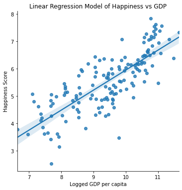

```python
# Plottoing the scatter plot as well as the linear regression line of
# countries happiness with respect to its GDP
seaborn.lmplot(data = data, x="Logged GDP per capita",
                    y="Happiness Score", )
plt.title("Linear Regression Model of Happiness vs GDP")
```

What we can determine based on the model and [linear regression](https://scikit-learn.org/stable/modules/generated/sklearn.linear_model.LinearRegression.html) line is that GDP and Happiness score have a positive relationship with eachother. As GDP increases, happiness score also increases. Now for extra analysis we will also look at the graph again, however, this time each plot is grouped based on region and we remove the regression line for visual clarity.

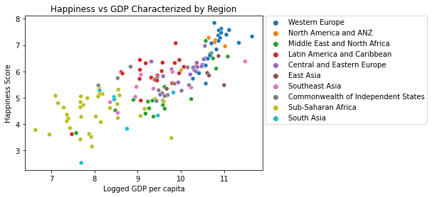

```python
# Plotting the scatterplot without the linear regression line
# and with each plot grouped
seaborn.scatterplot(data = data, x="Logged GDP per capita",
                    y="Happiness Score", hue = "Regional indicator")

# Create an informative title that is respective of the graph
plt.title("Happiness vs GDP Characterized by Region")

# Moving the legend out of the graph for clarity
plt.legend(bbox_to_anchor=(1.01, 1),
           borderaxespad=0)
```

What we can notice from this graph is that each region of the world generally has its own GDP range. Western Europian countries are rich in GDP but also have the highest happiness scores followed by North America in both GDP and happiness score. Near the lower area of the list are Sub-Saharan Africa with a wide range of GDP and towards the lower happiness scores. However, GDP is far from the only factor and its important we look at the other causes while keeping region in the back of our minds.

#### Conclusion on the influence of GDP on Happiness Score

Its clear that GDP has a significant influence on a countries Happiness. This is apparent from the near linear shape of each countries plot with respect to GDP and happiness. Basically saying that the graph itself is a linear graph. It also important to note that countries within the same region will also have around the same GDP and as a result around the same happiness score. Although there are some outliers in the mix, it looks to be uniform. Western Europe being the region leading in both GDP and Happiness score follow by the North America and ANZ. To determine a countries happiness score, we need to look at the other factors as they may have more of a direct impact.

### Happiness vs Social Support

However, this time instead of creating two graphs for each factor (one containing linear regression and other grouping), we are combining them into one graph. Previously, it was for clarification purposes but now to understand the many factors while not overloading ourselves.

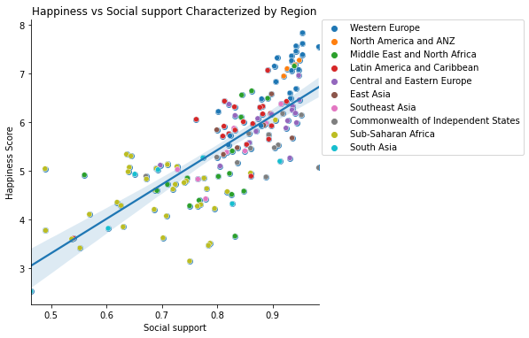

```python
# Ploting Happiness score with respect to Social Suport this time
# while also plotting the linear regression
seaborn.lmplot(data = data, x="Social support",
                    y="Happiness Score", )

# Color coding each plot on the scatter plot
seaborn.scatterplot(data = data, x="Social support",
                    y="Happiness Score", hue = "Regional indicator")

# Create an informative title that is respective of the graph
plt.title("Happiness vs Social support Characterized by Region")

# Moving the legend out of the graph for clarity
plt.legend(bbox_to_anchor=(1.01, 1),
           borderaxespad=0)
```

With this graph we can cleary see that many countries are towards the farthest edge of the social support score. These regions include Western Europe, North America and ANZ, some Middle East and North African, some Central and Eastern Europe, and even some independent states. What we can infer is that while many states are have incredibly high social support scores, the range of happiness scores are much wider. We can see this clear correlation by reducing our table.

```python
# Grab certain datapoints relevant to this analysis which are country name, regional indicator, happiness score, and social support
data2 = data[["Country name", "Regional indicator", "Happiness Score", "Social support"]]

# Remove all values that have social support scores below .9
data2 = data2[data2["Social support"] > .9]

# Sort the dataframe based on social support score in descending value
data2 = data2.sort_values(by=['Social support'], ascending = False)

print("Mean: " + str(data2["Happiness Score"].mean()))
data2
```

```
Mean: 6.612575
```

|  | Country name | Regional indicator | Happiness Score | Social support |
| --- | --- | --- | --- | --- |
| 96 | Turkmenistan | Commonwealth of Independent States | 5.066 | 0.983 |
| 3 | Iceland | Western Europe | 7.554 | 0.983 |
| 5 | Norway | Western Europe | 7.392 | 0.954 |
| 1 | Denmark | Western Europe | 7.620 | 0.954 |
| 0 | Finland | Western Europe | 7.842 | 0.954 |
| 44 | Kazakhstan | Commonwealth of Independent States | 6.152 | 0.952 |
| 28 | Slovenia | Central and Eastern Europe | 6.461 | 0.948 |
| 8 | New Zealand | North America and ANZ | 7.277 | 0.948 |
| 14 | Ireland | Western Europe | 7.085 | 0.947 |
| 17 | Czech Republic | Central and Eastern Europe | 6.965 | 0.947 |
| 52 | Hungary | Central and Eastern Europe | 5.992 | 0.943 |
| 2 | Switzerland | Western Europe | 7.571 | 0.942 |
| 20 | France | Western Europe | 6.690 | 0.942 |
| 4 | Netherlands | Western Europe | 7.464 | 0.942 |
| 39 | Estonia | Central and Eastern Europe | 6.189 | 0.941 |
| 10 | Australia | North America and ANZ | 7.183 | 0.940 |
| 11 | Israel | Middle East and North Africa | 7.157 | 0.939 |
| 33 | Slovakia | Central and Eastern Europe | 6.331 | 0.936 |
| 69 | Mongolia | East Asia | 5.677 | 0.935 |
| 37 | Lithuania | Central and Eastern Europe | 6.255 | 0.935 |
| 9 | Austria | Western Europe | 7.268 | 0.934 |
| 6 | Sweden | Western Europe | 7.363 | 0.934 |
| 16 | United Kingdom | Western Europe | 7.064 | 0.934 |
| 26 | Spain | Western Europe | 6.491 | 0.932 |
| 87 | Bulgaria | Central and Eastern Europe | 5.266 | 0.931 |
| 22 | Malta | Western Europe | 6.602 | 0.931 |
| 50 | Latvia | Central and Eastern Europe | 6.032 | 0.927 |
| 13 | Canada | North America and ANZ | 7.103 | 0.926 |
| 30 | Uruguay | Latin America and Caribbean | 6.431 | 0.925 |
| 59 | Croatia | Central and Eastern Europe | 5.882 | 0.924 |
| 18 | United States | North America and ANZ | 6.951 | 0.920 |
| 41 | Uzbekistan | Commonwealth of Independent States | 6.179 | 0.918 |
| 31 | Singapore | Southeast Asia | 6.377 | 0.915 |
| 88 | Maldives | South Asia | 5.198 | 0.913 |
| 74 | Belarus | Commonwealth of Independent States | 5.534 | 0.910 |
| 7 | Luxembourg | Western Europe | 7.324 | 0.908 |
| 19 | Belgium | Western Europe | 6.834 | 0.906 |
| 49 | Mauritius | Sub-Saharan Africa | 6.049 | 0.905 |
| 75 | Russia | Commonwealth of Independent States | 5.477 | 0.903 |
| 12 | Germany | Western Europe | 7.155 | 0.903 |

Taking a simple look at the dataframe, we can see that the countries with highest social support will not always have the highest happiness score. This is especially apparent with the mean happiness score of countries with above .9 social support being only 6.6. We can even take a further visual analysis of this by graphing it.

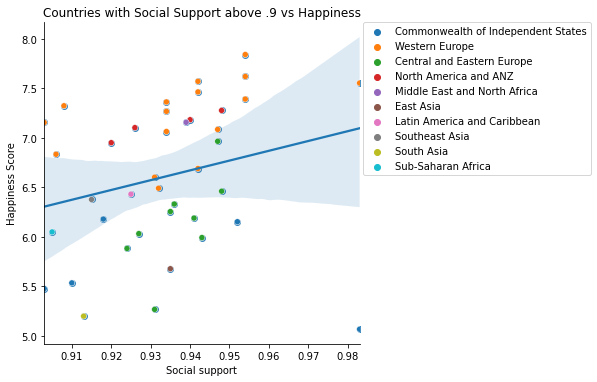

```python
# Creating the linear regression plot
seaborn.lmplot(data = data2, x="Social support",
                    y="Happiness Score", )

# Color coding each plot on the scatter plot
seaborn.scatterplot(data = data2, x="Social support",
                    y="Happiness Score", hue = "Regional indicator")

# Create an informative title that is respective of the graph
plt.title("Countries with Social Support above .9 vs Happiness")

# Moving the legend out of the graph for clarity
plt.legend(bbox_to_anchor=(1.01, 1),
           borderaxespad=0)
```

Again we see that Western Europe have the highest happiness scores but not always having the absolute highest social support. Many countries with high social support regions such as independent states have subpar happiness scores compared to western europian countries. Some countries even hitting as low as around 5.2 while having the highest social support scores.

#### Conclusion on the influence of Social Support on Happiness

Its clear from the linear regression line of the original graph that overall, social support does indeed have a positive relationship with a countries happiness. However, as we began to dive deeper into the data, we found that your social support may not have as much linear impact as we have thought. This trend reminds me of the law of dimishing returns which basically states that as you push the boundaries on your input you get less and less ouput. In this case, if you have low social support then any increase in social support will have a large increase in happiness score. On the other hand, if you already have a high social support score, any further increase in social support will yield lesser increase in happiness score.

### Happiness vs Life Expectancy

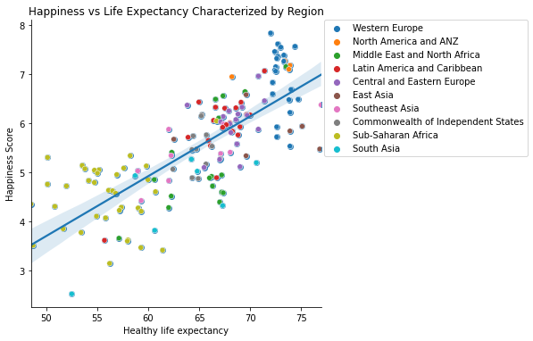

```python
# Ploting Happiness score with respect to Life Expectancy this time
# while also plotting the linear regression
seaborn.lmplot(data = data, x="Healthy life expectancy",
                    y="Happiness Score", )

# Color coding each plot on the scatter plot
seaborn.scatterplot(data = data, x="Healthy life expectancy",
                    y="Happiness Score", hue = "Regional indicator")

# Create an informative title that is respective of the graph
plt.title("Happiness vs Life Expectancy Characterized by Region")

# Moving the legend out of the graph for clarity
plt.legend(bbox_to_anchor=(1.01, 1),
           borderaxespad=0)
```

With this graph we can see a similar relationship as the one shown between GDP and happiness. It looks to be overall linear and visually doesn't seem to hold any dimishing returns. However, we should also take one last look between each regions life expectancy and each regions happiness. In the next graph we will be comparing regional happiness and regional life expectancy in a subplot fashion side by side to determine any anomaly in position relative to each other.

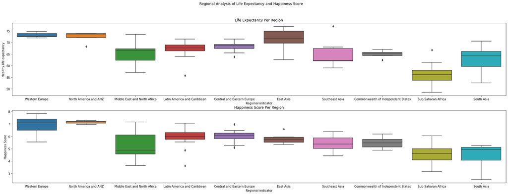

```python
# Create multiple plots side by side to spot any extreme difference.
fig, axes = plt.subplots(2, 1, figsize = (30, 10))

# Create an informative title that connects both plots
fig.suptitle("Regional Analysis of Life Expectancy and Happiness Score")

# Setting individual titles for each plot
axes[0].set_title("Life Expectancy Per Region")
axes[1].set_title("Happiness Score Per Region")

# Creating a boxplots for each subplot based on the title we gave the subplots
seaborn.boxplot(data = data, x = "Regional indicator",
                   y = "Healthy life expectancy", ax = axes[0])
seaborn.boxplot(data = data, x = "Regional indicator",
                   y = "Happiness Score", ax = axes[1])
```

#### Conclusion on the influence of life expectancy on happiness

Overall, life expectancy has a linear and positive impact on a countries happiness. Based on the original graph showing a visual linear relationship with what looks to be no dimishing return, we can say that life expectancy has a large impact on happiness. Even though we found anomlies from the second graph pertaining to East Asia and Sub-Saharan Africa, eight out of the ten regions were plotted as expected relative to eachother postion. Therefore, it isn't strong enough evidence to disprove the fact that life expectancy has a large and positive impact on happiness.

### Happiness vs Freedom

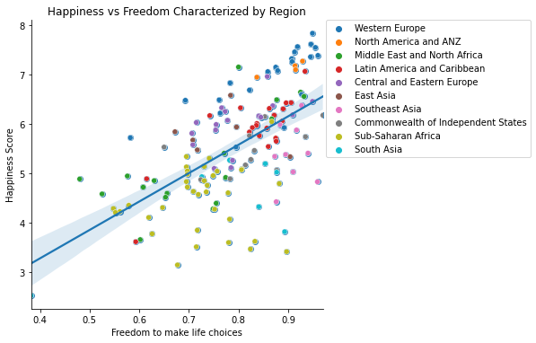

```python
# Ploting Happiness score with respect to freedom this time
# while also plotting the linear regression
seaborn.lmplot(data = data, x="Freedom to make life choices",
                    y="Happiness Score", )

# Again making sure to color code the data
seaborn.scatterplot(data = data, x="Freedom to make life choices",
                    y="Happiness Score", hue = "Regional indicator")

# Create an informative title that is respective of the graph
plt.title("Happiness vs Freedom Characterized by Region")

# Moving the legend out of the graph for clarity
plt.legend(bbox_to_anchor=(1.01, 1),
           borderaxespad=0)
```

```python
# Grab data nessary to this analysis
data3 = data[["Country name", "Regional indicator", "Happiness Score", "Freedom to make life choices"]]

# Grab only countries with freedom scores above .85
data3 = data3[data3["Freedom to make life choices"] > .85]

# Printing the range of happiness scores of countries with above .85 freedom scores
print("Range on Happiness Score for Countries with atleast .85 Freedom Scores: " + str(data3["Happiness Score"].min()) + " - " + str(data3["Happiness Score"].max()))

# Printing the mean happiness scores of countries with freedom scores of above .85
print("Mean based on .85 freedom: " + str(data3["Happiness Score"].mean()))
print("Regular mean: " + str(data["Happiness Score"].mean()))

# Sorting based on Freedom scores
data3.sort_values(by = ["Freedom to make life choices"], ascending = False)
```

```
Range on Happiness Score for Countries with atleast .85 Freedom Scores: 3.415 - 7.842
Mean based on .85 freedom: 6.208464285714285
Regular mean: 5.532838926174494
```

|  | Country name | Regional indicator | Happiness Score | Freedom to make life choices |
| --- | --- | --- | --- | --- |
| 41 | Uzbekistan | Commonwealth of Independent States | 6.179 | 0.970 |
| 5 | Norway | Western Europe | 7.392 | 0.960 |
| 113 | Cambodia | Southeast Asia | 4.830 | 0.959 |
| 3 | Iceland | Western Europe | 7.554 | 0.955 |
| 0 | Finland | Western Europe | 7.842 | 0.949 |
| 28 | Slovenia | Central and Eastern Europe | 6.461 | 0.949 |
| 1 | Denmark | Western Europe | 7.620 | 0.946 |
| 6 | Sweden | Western Europe | 7.363 | 0.945 |
| 78 | Vietnam | Southeast Asia | 5.411 | 0.940 |
| 66 | Kyrgyzstan | Commonwealth of Independent States | 5.744 | 0.935 |
| 15 | Costa Rica | Latin America and Caribbean | 7.069 | 0.934 |
| 24 | United Arab Emirates | Middle East and North Africa | 6.561 | 0.932 |
| 8 | New Zealand | North America and ANZ | 7.277 | 0.929 |
| 31 | Singapore | Southeast Asia | 6.377 | 0.927 |
| 22 | Malta | Western Europe | 6.602 | 0.927 |
| 21 | Bahrain | Middle East and North Africa | 6.647 | 0.925 |
| 2 | Switzerland | Western Europe | 7.571 | 0.919 |
| 60 | Philippines | Southeast Asia | 5.880 | 0.917 |
| 13 | Canada | North America and ANZ | 7.103 | 0.915 |
| 10 | Australia | North America and ANZ | 7.183 | 0.914 |
| 4 | Netherlands | Western Europe | 7.464 | 0.913 |
| 99 | Laos | Southeast Asia | 5.030 | 0.910 |
| 39 | Estonia | Central and Eastern Europe | 6.189 | 0.909 |
| 9 | Austria | Western Europe | 7.268 | 0.908 |
| 7 | Luxembourg | Western Europe | 7.324 | 0.907 |
| 29 | Guatemala | Latin America and Caribbean | 6.435 | 0.906 |
| 83 | China | East Asia | 5.339 | 0.904 |
| 146 | Rwanda | Sub-Saharan Africa | 3.415 | 0.897 |
| 30 | Uruguay | Latin America and Caribbean | 6.431 | 0.896 |
| 80 | Malaysia | Southeast Asia | 5.384 | 0.895 |
| 138 | India | South Asia | 3.819 | 0.893 |
| 57 | Portugal | Western Europe | 5.929 | 0.892 |
| 36 | Jamaica | Latin America and Caribbean | 6.309 | 0.890 |
| 48 | El Salvador | Latin America and Caribbean | 6.061 | 0.888 |
| 53 | Thailand | Southeast Asia | 5.985 | 0.884 |
| 114 | Mozambique | Sub-Saharan Africa | 4.794 | 0.882 |
| 14 | Ireland | Western Europe | 7.085 | 0.879 |
| 100 | Bangladesh | South Asia | 5.025 | 0.877 |
| 96 | Turkmenistan | Commonwealth of Independent States | 5.066 | 0.877 |
| 25 | Saudi Arabia | Middle East and North Africa | 6.494 | 0.877 |
| 125 | Myanmar | Southeast Asia | 4.426 | 0.876 |
| 70 | Paraguay | Latin America and Caribbean | 5.653 | 0.876 |
| 68 | Bolivia | Latin America and Caribbean | 5.716 | 0.875 |
| 12 | Germany | Western Europe | 7.155 | 0.875 |
| 81 | Indonesia | Southeast Asia | 5.345 | 0.873 |
| 40 | Panama | Latin America and Caribbean | 6.180 | 0.872 |
| 32 | Kosovo | Central and Eastern Europe | 6.372 | 0.869 |
| 49 | Mauritius | Sub-Saharan Africa | 6.049 | 0.867 |
| 46 | Kuwait | Middle East and North Africa | 6.106 | 0.867 |
| 35 | Mexico | Latin America and Caribbean | 6.317 | 0.862 |
| 72 | Dominican Republic | Latin America and Caribbean | 5.545 | 0.860 |
| 16 | United Kingdom | Western Europe | 7.064 | 0.859 |
| 17 | Czech Republic | Central and Eastern Europe | 6.965 | 0.858 |
| 58 | Honduras | Latin America and Caribbean | 5.919 | 0.857 |
| 88 | Maldives | South Asia | 5.198 | 0.854 |
| 44 | Kazakhstan | Commonwealth of Independent States | 6.152 | 0.853 |

### Happiness vs Generosity

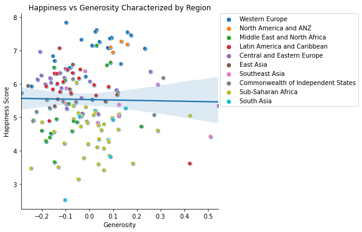

```python
# Ploting Happiness score with respect to generosity this time
# while also plotting the linear regression
seaborn.lmplot(data = data, x="Generosity",
                    y="Happiness Score", )

# Again making sure to color code the data
seaborn.scatterplot(data = data, x="Generosity",
                    y="Happiness Score", hue = "Regional indicator")

# Create an informative title that is respective of the graph
plt.title("Happiness vs Generosity Characterized by Region")

# Moving the legend out of the graph for clarity
plt.legend(bbox_to_anchor=(1.01, 1),
           borderaxespad=0)
```

Here, it only takes one graph to know that generosity does not have a positive impact on happiness. It's clear as day based on many countries happiness with respect to generosity. The countries with the highest happiness scores have even negative geneorisity scores. Some countries who have extremely high generosity scores have median happiness scores. In fact, the linear regression line appears to be slight negative leaning. We can figure that out by calculating the [linear regression](https://scikit-learn.org/stable/modules/generated/sklearn.linear_model.LinearRegression.html).

```python
# Calculate the linear regression line based on generosity and happiness score
model = LinearRegression().fit(data['Generosity'].values.reshape(-1,1), data['Happiness Score'])

# I then printed out the model to understand it
print("Y = " + str(model.coef_[0]) + "x + " + str(model.intercept_))
```

```
Y = -0.12687827965307963x + 5.530918721338137
```

#### Conclusion on the influence of generosity on happiness

Based on the linear regression line we can clearly see that generosity does not have a linear nor positive impact. In fact, when we calculated the linear regression line we can see that an increase in generosity has a decrease in happiness score. This is shown by the coefficient -0.12687 on the linear regression equation we calculated out. Based on these findings, we can conlcude that all the other factors we have analyzed today have a much larger impact on a countries happiness than generosity.

### Happiness vs Corruption

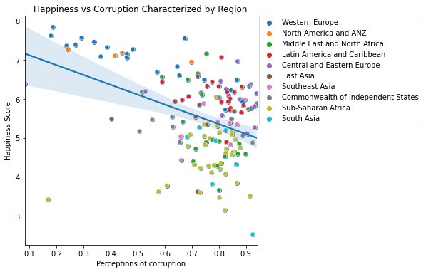

```python
# Ploting Happiness score with respect to corruption
# while also plotting the linear regression
seaborn.lmplot(data = data, x="Perceptions of corruption",
                    y="Happiness Score", )

# Again making sure to color code the data
seaborn.scatterplot(data = data, x="Perceptions of corruption",
                    y="Happiness Score", hue = "Regional indicator")

# Create an informative title that is respective of the graph
plt.title("Happiness vs Corruption Characterized by Region")

# Moving the legend out of the graph for clarity
plt.legend(bbox_to_anchor=(1.01, 1),
           borderaxespad=0)
```

Before we make any analysis, it's important to note that high scores of perceptions of corruptions means that the public believe with high certainty that the government is corrupt. **Not** that the government is corrput, only the belief of the citizens. Therefore, in a way we should be looking at this graph backwards. High perceptions of corruptions is bad and lower values are good. Therefore, we expect that the relationship between happiness and corruption are inverted (expectation: high herception = low happiness).

```python
# Grab data nessary to this analysis
data4 = data[["Country name", "Regional indicator", "Happiness Score", "Perceptions of corruption"]]

# Grab only countries with freedom scores above .85
data4 = data4[data4["Perceptions of corruption"] > .85]

# Printing the range of happiness scores of countries with above .85 freedom scores
print("Range on Happiness Score for Countries with atleast .5 corruption Scores: " + str(data4["Happiness Score"].min()) + " - " + str(data4["Happiness Score"].max()))

# Printing the mean happiness scores of countries with freedom scores of above .85
print("Mean based on .5 corruption: " + str(data4["Happiness Score"].mean()))
print("Regular mean: " + str(data["Happiness Score"].mean()))

# Sorting based on Freedom scores
data4.sort_values(by = ["Perceptions of corruption"], ascending = False)
```

[output not shown]

|  | Country name | Regional indicator | Happiness Score | Perceptions of corruption |
| --- | --- | --- | --- | --- |
| 59 | Croatia | Central and Eastern Europe | 5.882 | 0.939 |
| 45 | Romania | Central and Eastern Europe | 6.140 | 0.938 |
| 87 | Bulgaria | Central and Eastern Europe | 5.266 | 0.932 |
| 63 | Bosnia and Herzegovina | Central and Eastern Europe | 5.813 | 0.931 |
| 109 | Ukraine | Commonwealth of Independent States | 4.875 | 0.924 |
| 148 | Afghanistan | South Asia | 2.523 | 0.924 |
| 64 | Moldova | Commonwealth of Independent States | 5.766 | 0.918 |
| 32 | Kosovo | Central and Eastern Europe | 6.372 | 0.917 |
| 144 | Lesotho | Sub-Saharan Africa | 3.512 | 0.915 |
| 33 | Slovakia | Central and Eastern Europe | 6.331 | 0.911 |
| 66 | Kyrgyzstan | Commonwealth of Independent States | 5.744 | 0.908 |
| 93 | North Macedonia | Central and Eastern Europe | 5.101 | 0.905 |
| 92 | Albania | Central and Eastern Europe | 5.117 | 0.901 |
| 122 | Lebanon | Middle East and North Africa | 4.584 | 0.898 |
| 53 | Thailand | Southeast Asia | 5.985 | 0.895 |
| 62 | Peru | Latin America and Caribbean | 5.840 | 0.891 |
| 96 | Turkmenistan | Commonwealth of Independent States | 5.066 | 0.888 |
| 57 | Portugal | Western Europe | 5.929 | 0.887 |
| 36 | Jamaica | Latin America and Caribbean | 6.309 | 0.884 |
| 70 | Paraguay | Latin America and Caribbean | 5.653 | 0.882 |
| 115 | Nigeria | Sub-Saharan Africa | 4.759 | 0.878 |
| 52 | Hungary | Central and Eastern Europe | 5.992 | 0.876 |
| 110 | Iraq | Middle East and North Africa | 4.854 | 0.875 |
| 121 | Tunisia | Middle East and North Africa | 4.596 | 0.870 |
| 17 | Czech Republic | Central and Eastern Europe | 6.965 | 0.868 |
| 81 | Indonesia | Southeast Asia | 5.345 | 0.867 |
| 27 | Italy | Western Europe | 6.483 | 0.866 |
| 137 | Sierra Leone | Sub-Saharan Africa | 3.849 | 0.866 |
| 128 | Sri Lanka | South Asia | 4.325 | 0.863 |
| 102 | South Africa | Sub-Saharan Africa | 4.956 | 0.860 |
| 69 | Mongolia | East Asia | 5.677 | 0.856 |
| 40 | Panama | Latin America and Caribbean | 6.180 | 0.856 |
| 118 | Uganda | Sub-Saharan Africa | 4.636 | 0.855 |

We can see based on the range we found that the bulk of our data points have happiness scores between 2.5 and 6.9. Values being extrememly low to not extremely high relative to others (top countries have higher happiness scores). We can also see that the mean of our happiness scores for the bulk of our data being less than the regular average. This is in part due to excluding some of the highest happiness score countries.

## Overall Conclusion and Final Thoughts

We have determined that a countries happiness is mainly dependent on (in order on decreasing influence) GDP per capita, life expectancy, and social support. Other factors such as freedom, generosity, and corruption are shown to have much less impact. Freedom having more impact than both generosity and corruption. Generosity having a negative impact on a countries happiness score. While corruption has shows to have impact on happiness but it shown to have little impact (High corruption does not always mean low happiness scores).

This does help explain the fact that COVID-19 decreasing overall societal happiness. It is in part due to the main factors that influence a countries happiness. Global economic trade has declined significanly while a nations economy plumetts due to covid. Unbeknownst, to me a countries GDP heavily affects the socities health. A declining and weak economy will result in an unhappy countries. Also, social life has also been nearly shutoff as a result of covid and social support has a strong influence on a countries happiness. Now that the economy is on a stronger recovery and social life has begun to get back to normal, I feel happier as a result. This was due to the main factors that influence societies happiness as a whole which were GDP (tied to economy) and social support (tied to social life).